# Puget Sound Downscaling

Loading files

```r
source("libraries.R")
source("map_Puget_Sound.R")
source("get_nc.R")
source("get_historical_nc.R")
source("combine_ncfiles.R")
source("regrid_ncfiles.R")
source("climatology_nc.R")
source("calc_anomaly.R")
source("interpolate_nc.R")
source("overlay_anomaly.R")
source("plot_interpolated_SST_anomaly.R")
#commented because it is a script and not a function
#source("plot_nc.R")
```

Creating Puget Sound Map

[output not shown]

[output not shown]

```
True north is not meaningful without coord_sf()Using plotunit = 'm'
```

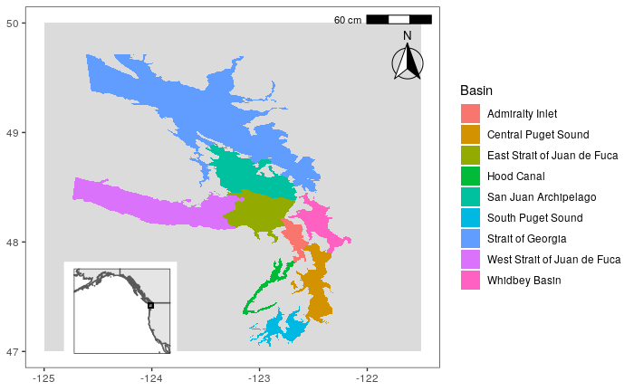

```r
make_map(shape.file = "~/Puget_Sound_Downscaling/Atlantis_shapefile/bgm_Puget_Sound_89b_0p0001_WGS84.shp", basin.shapefile = "~/Puget_Sound_Downscaling/repsbasin_shapefile/shapefile_4071.shp", file.name = "puget_sound_map.jpg", scale.factor = 1, arrow.position = "tr", min.long = -124.555, max.long = -121.9, min.lat = 46.9936, max.lat = 48.957)
```

Downloading initial files to test resolution

```r
model.list = c("HadGEM3-GC31-LL","EC-Earth3", "MRI-ESM2-0", "NorESM2-LM", "NorESM2-MM", "CMCC-CM2-SR5", "AWI-CM-1-1-MR")
lapply(model.list, get_nc)
system("az vm deallocate --name atlantisserver01 --no-wait --resource-group morzariacedogroup")

#get_nc(model.name = "AWI-CM-1-1-MR")
```

Downloading more files to test resolution - These are higher resolution models that didn’t run all as many ScenarioMIPs, so they were downloaded using ssp245

```r
model.list2 = c("GFDL-CM4", "GFDL-ESM2M", "CMCC-CM2-SR5")
lapply(model.list2, get_nc)
system("az vm deallocate --name atlantisserver01 --no-wait --resource-group morzariacedogroup")
```

Downloading even more files to test resolution -GFDL and CMCC but with monthly data

```r
model.list3 = c("GFDL-CM4", "CMCC-CM2-SR5")
lapply(model.list3, get_nc)
system("az vm deallocate --name atlantisserver01 --no-wait --resource-group morzariacedogroup")
```

Plotting model resolutions

```r
source("plot_CNRM-CM6-1-HR.R")
```

[output not shown]

Download SST data for all scenarios

```r
model.list.download  <- c("GFDL-CM4", "CNRM-CM6-1-HR")
#model.list.download  <- c("CNRM-CM6-1-HR")

#sets working directory
setwd("~/Puget_Sound_Downscaling/data_files/")

#ScenarioMIP

data.cimp6.sc <- lapply(model.list.download, get_nc, model.var = "tos") %>%
  bind_rows

#Historical data
#salinity is "sos"
data.cimp6.hist <- lapply(model.list.download, get_historical_nc, model.var = "tos") %>%
  bind_rows

data.cimp6.table <- bind_rows(data.cimp6.hist, data.cimp6.sc)

write_csv(data.cimp6.table, "data_cimp6_table.csv")

system("az vm deallocate --name atlantisserver01 --no-wait --resource-group morzariacedogroup")
```

Download salinity data for all scenarios

```r
model.list.download  <- c("GFDL-CM4", "CNRM-CM6-1-HR")
#model.list.download  <- c("CNRM-CM6-1-HR")

#sets working directory
setwd("~/Puget_Sound_Downscaling/data_files/")

#ScenarioMIP
#salinity is "sos"
data.cimp6.sc <- lapply(model.list.download, get_nc, model.var = "sos") %>%
  bind_rows

#Historical data
#salinity is "sos"
data.cimp6.hist <- lapply(model.list.download, get_historical_nc, model.var = "sos") %>%
  bind_rows

data.cimp6.table <- bind_rows(data.cimp6.hist, data.cimp6.sc)

write_csv(data.cimp6.table, "data_cimp6_table.csv")

system("az vm deallocate --name atlantisserver01 --no-wait --resource-group morzariacedogroup")
```

Combine multipart files into a single nc file

```r
# list of all files with gr: "data reported on a model's regular grid"
model.files <- list.files("~/Puget_Sound_Downscaling/data_files", pattern = "*_gr_*.*nc$")

# list of unique models and scenarios
model.scenarios <- list.files("~/Puget_Sound_Downscaling/data_files", pattern = "*_gr_*.*nc$") %>%
  str_split(.,"_gr") %>%
  unlist %>%
  #switch between sos and tos. You can do this manually here, then rerun. ( Note on 7/20/20)
  grep("sos_Omon",., value = TRUE) %>%
  unique()

data.path <- "~/Puget_Sound_Downscaling/data_files"
save.path <- "~/Puget_Sound_Downscaling/combined_data_files"
dir.create(save.path)

lapply(model.scenarios,combine_files, model.files, save.path, data.path)
```

Regrid files into common, highest resolution grid, in this case we are using GFDL-OM4p25 as the base grid

```r
# model resolution
# checked by opening nc file and printing open file
# open netCDF file
# ncin <- nc_open(this.nc)
# print(this.file) #lists basic info about file
# GFDL-CM4 is ocean: GFDL-OM4p25 (GFDL-MOM6, tripolar - nominal 0.25 deg; 1440 x 1080 longitude/latitude; 75 levels; top grid cell 0-2 m)
# CNRM-CM6-1-HR, ocean: Nemo 3.6 (eORCA025, tripolar primarily 1/4deg; 1442 x 1050 longitude/latitude

data.path <- "~/Puget_Sound_Downscaling/combined_data_files"
save.path <- "~/Puget_Sound_Downscaling/regridded_data_files"
wgts.dir <- "~/Puget_Sound_Downscaling/wgts_files"
#will create directory if it does not exist
dir.create(save.path)
dir.create(wgts.dir)

# list of all files with gn: "data reported on a model's native grid"
model.files <- list.files(path=data.path, pattern = "*.*nc$")
#switch variable here: sos or tos

mclapply(model.files, regrid_nc, save.path, data.path, wgts.dir, resolution = "1440x1080")
```

Calculate the climatology, the long term average for all nc files - GFDL files were moved from combined_data_files to regridded_data_files

```r
data.path <- "~/Puget_Sound_Downscaling/regridded_data_files"
save.path <- "~/Puget_Sound_Downscaling/climatology_files"
#will create directory if it does not exist
dir.create(save.path)

# list of all regridded files
model.files <- list.files(path=data.path, pattern = "*.*nc$")

# Calculate the number of cores
NumberOfCluster <- detectCores() - 1

# Initiate cluster
cl <- makeCluster(NumberOfCluster)
registerDoSNOW(cl)


point.data <- foreach(this.file = model.files, .verbose=TRUE) %dopar% {

  .packages = c(
    "tidyverse","ncdf4")

  if(length(.packages[!.inst]) > 0) install.packages(.packages[!.inst])

  # Load packages into session
  lapply(.packages, require, character.only=TRUE)

  stat.clim <- "mean"

  climatology_nc(this.file, stat.clim, data.path, save.path)

}
```

Calculate anomaly as the difference between the hindcast and the forecast

```r
data.path <- "~/Puget_Sound_Downscaling/climatology_files"
save.path <- "~/Puget_Sound_Downscaling/anomaly_files"
#will create directory if it does not exist
dir.create(save.path)

# list of unique climatology files
models.cimp6 <- list.files(data.path, pattern = "ssp*.*_mean_*.*nc$")
historical.files <- list.files(data.path, pattern = "historical*.*_mean_*.*nc$")

model.list <- c("CNRM-CM6-1-HR", "GFDL-CM4")

model.vars <- c("tos","sos")


lapply(model.list, anomaly_nc, models.cimp6, historical.files, model.vars)
```

Get SST from NOAA OI SST V2 High Resolution Dataset: NOAA 1/4° daily Optimum Interpolation Sea Surface Temperature (or daily OISST) is an analysis constructed by combining observations from different platforms (satellites, ships, buoys, and Argo floats) on a regular global grid. Reference is Reynolds, Richard W., Thomas M. Smith, Chunying Liu, Dudley B. Chelton, Kenneth S. Casey, Michael G. Schlax, 2007: Daily High-Resolution-Blended Analyses for Sea Surface Temperature. J. Climate, 20, 5473-5496. Cite as “NOAA High Resolution SST data provided by the NOAA/OAR/ESRL PSL, Boulder, Colorado, USA, from their Web site at https://psl.noaa.gov/”

```r
system("wget ftp://ftp.cdc.noaa.gov/Datasets/noaa.oisst.v2.highres/sst.day.mean.ltm.1982-2010.nc", wait=TRUE)
```

```r
system("wget https://data.nodc.noaa.gov/thredds/fileServer/ncei/woa/temperature/decav/0.25/woa18_decav_t00_04.nc", wait =TRUE)

system("wget https://data.nodc.noaa.gov/thredds/fileServer/ncei/woa/salinity/decav/0.25/woa18_decav_s00_04.nc", wait=TRUE)
```

Get SST from RDA dataset ds548.0 - ’International Comprehensive Ocean-Atmosphere Data Set (ICOADS) Release 3, Individual Observations

```r
system("wget https://rda.ucar.edu/dsrqst/WALKER439286/ICOADS_R3.0_Rqst439286_19700101-19950422.csv.gz", wait=TRUE)
```

Interpolate values at 3km

```r
#GSHHS_f_L1 is layer imported from GIS with land shape.

landShape <- readOGR("~/Puget_Sound_Downscaling/landshape_shapefile/", "GSHHS_f_L1")

# crop it to just puget sound, same as raster projection
extent.study <- extent(-130, -121.5, 46, 51.5)
PugetSoundLandShape <- crop(landShape,extent.study)
#creating empty raster with 3km cell resolution
pred.raster <- raster(res=0.03)
#constrain raster to Puget Sound area
pred.raster.ext <- setExtent(pred.raster,extent.study,keepres = TRUE)
#convert polygon to raster using empty raster
PugetSoundRaster  <- rasterize(PugetSoundLandShape,pred.raster.ext,'level')
PugetSoundRaster <- setExtent(PugetSoundRaster, extent.study,keepres = TRUE)
plot(PugetSoundRaster)

#switch land values to NA, ocean to 1
PugetSoundRaster[is.na(PugetSoundRaster)] <- 2
PugetSoundRaster[PugetSoundRaster==1] <- NA
PugetSoundRaster[PugetSoundRaster==2] <- 1

data.path <- "~/Puget_Sound_Downscaling/anomaly_files"
save.path <- "~/Puget_Sound_Downscaling/3km_interpolated_files"
dir.create(save.path)

file.list <- list.files(data.path, pattern = "*.*nc$")
lapply(file.list, InterpolateData,PugetSoundRaster,data.path,save.path)
```

Plot Interpolated SST Anomalies for Salish Sea

```r
data.path<- "~/Puget_Sound_Downscaling/3km_interpolated_files/"
save.path<- "~/Puget_Sound_Downscaling/interpolated_anomaly_plots/"
#will create directory if it does not exist
dir.create(save.path)

file.list <- list.files(data.path, pattern = "tos*.*.*asc$")

lapply(file.list, plot_SSTanomaly,data.path,save.path)
```

Plot Interpolated Salinity Anomalies for Salish Sea

```r
lapply(file.list, plot_salinity_anomaly,data.path,save.path)
```

[output not shown]

[output cut: 28 more lines]

```

[[8]]
NULL

[[9]]
NULL

[[10]]
NULL

[[11]]
NULL

[[12]]
NULL
```

Plot Faceted Interpolated Anomaly Figure

```r
setwd("~/Puget_Sound_Downscaling/interpolated_anomaly_plots/")
plot1 <- readPNG('sos_Omon_GFDL-CM4_ssp585_r1i1p1f1_anomaly_202001-205012_plot.png')
plot2 <- readPNG('sos_Omon_GFDL-CM4_ssp585_r1i1p1f1_anomaly_207001-210012_plot.png')
plot3 <- readPNG('tos_Omon_GFDL-CM4_ssp585_r1i1p1f1_anomaly_202001-205012_plot.png')
plot4 <- readPNG('tos_Omon_GFDL-CM4_ssp585_r1i1p1f1_anomaly_207001-210012_plot.png')

grid.combine <- grid.arrange(rasterGrob(plot1),rasterGrob(plot2),rasterGrob(plot3),rasterGrob(plot4),ncol=2)

ggsave(grid.combine, filename = "Fig3_Salish_Sea_Interpolated_Anomalies.png", device = "png", path = "~/Puget_Sound_Downscaling/final_figures/",
       dpi = 100, width = 24, height = 20, units = "cm")
```

```r
#GSHHS_f_L1 is layer imported from GIS with land shape.

landShape <- readOGR("~/Puget_Sound_Downscaling/landshape_shapefile/", "GSHHS_f_L1")

# crop it to just puget sound, same as raster projection
extent.study <- extent(-130, -121.5, 46, 51.5)
PugetSoundLandShape <- crop(landShape,extent.study)
ps.crs <- crs(PugetSoundLandShape)

#creating empty raster with 3km cell resolution
pred.raster <- raster(extent.study, res=0.001)
PugetSoundRaster  <- rasterize(PugetSoundLandShape,pred.raster,'level')
plot(PugetSoundRaster)

#switch land values to NA, ocean to 1
PugetSoundRaster[is.na(PugetSoundRaster)] <- 2
PugetSoundRaster[PugetSoundRaster==1] <- NA
PugetSoundRaster[PugetSoundRaster==2] <- 1

data.path <- "~/Puget_Sound_Downscaling/anomaly_files"
save.path <- "~/Puget_Sound_Downscaling/interpolated_files"
dir.create(save.path)

file.list <- list.files(data.path, pattern = "*.*nc$")

#always check computer size
NumberOfCluster <- detectCores() - 4

# Initiate cluster
cl <- makeCluster(NumberOfCluster)
registerDoSNOW(cl)


interpolated.data <- foreach(this.file = file.list, .verbose=TRUE) %dopar% {

  .packages = c("fields","ncdf4","sf","rgdal","raster","stringr")

  if(length(.packages[!.inst]) > 0) install.packages(.packages[!.inst])

  # Load packages into session
  lapply(.packages, require, character.only=TRUE)

  InterpolateData(this.file, PugetSoundRaster,data.path,save.path)

}
```

Take original ROMS time series and overlay anomalies

```r
setwd("~/Puget_Sound_Downscaling/Atlantis_shapefile/")
PugetSoundAtlantisPolygons  <- readOGR(".","bgm_Puget_Sound_89b_0p0001_WGS84")
#plot(PugetSoundAtlantisPolygons, add=TRUE)

#temperature ROMS time series used to drive Atlantis
# 2yr timeseries for 2005 and 2006, timestep is 12 hours

atlantis.temp.roms <- "pugetsound_roms_temp.nc"

atlantis.salt.roms <- "pugetsound_roms_salt.nc"

#dim(temperatureArray)
#[1]    7   89 1460
# Note this is layers 1-7,  listed as deepest to shallowest, then blanks, then sediemntn. See user manual.

#---------------
# Need to get the number of depth layers for each of the 89 Atlantis polygons, and a count of total num polygons
AtlantisBoxInfo <- read.csv(paste0("~/Puget_Sound_Downscaling/roms_forcing/","AtlantisBoxInfo.csv"))
#AtlantisBoxInfo$num_layers
#AtlantisBoxInfo$box_id

data.path <- "~/Puget_Sound_Downscaling/interpolated_files"
forcing.path <- "~/Puget_Sound_Downscaling/roms_forcing"

save.path <- "~/Puget_Sound_Downscaling/overlay_files"
dir.create(save.path)

file.list <- list.files(data.path, pattern = "*.*asc$")

 lapply(file.list,overlay_roms, PugetSoundAtlantisPolygons, AtlantisBoxInfo,atlantis.temp.roms, atlantis.salt.roms, data.path, save.path)
```

Combining the ROMS time series to prepare for plotting

```r
data.path <- "~/Puget_Sound_Downscaling/overlay_files"
save.path <- "~/Puget_Sound_Downscaling/"
setwd(data.path)

files.overlay <- list.files(data.path, pattern = "*.csv", full.names = TRUE)

get_file <- function(this.file) {

  file_data<- fread(this.file) %>%
    as_tibble() %>%
    mutate(file_name= gsub("/home/atlantis/Puget_Sound_Downscaling/overlay_files/", "", this.file)) %>%
    mutate(boxIndex= boxIndex-1)# %>%
    #mutate(day = timestep/2) %>%
    #mutate(month = seq(as.Date("2005/1/1"), by = "day", length.out = 87600))

  return(file_data)

}

data.downscaled <- lapply(files.overlay, get_file) %>%
  bind_rows()

data.downscaled.table <- data.downscaled %>%
    separate(file_name,
             into=c("variable",
                    "realm",
                    "model",
                    "experiment",
                    "realisation",
                    "stat",
                    "date"),
             sep = "_")
setwd("~/Puget_Sound_Downscaling/")
write_csv(data.downscaled.table, "data_downscaled_table.csv")
```

Grouping downscaled data to prepare for plotting

```r
data.downscaled.table<- read_csv("data_downscaled_table.csv")

#including box
box.SST.grouping <- data.downscaled.table %>%
  group_by(variable, model, experiment, boxIndex, date) %>%
  filter(variable=="tos") %>%
  summarize(mean.roms_original = mean(roms_original),
            mean.roms_cimp6 = mean(roms_cimp6)) %>%
  ungroup() %>%
  mutate(term=if_else(date =="202001-205012roms.csv", "Short-term",
                      if_else(date =="207001-210012roms.csv", "Long-term", "NA")))

setwd("~/Puget_Sound_Downscaling/Atlantis_shapefile/")
PugetSoundAtlantisPolygons  <-readOGR(".","bgm_Puget_Sound_89b_0p0001_WGS84")
#plot(PugetSoundAtlantisPolygons, add=TRUE)
library(broom)
spdf_fortified <- tidy(PugetSoundAtlantisPolygons, region = "code")
```

Plotting final figures

```r
setwd("~/Puget_Sound_Downscaling/")

#Figure 4 - plots SST 4 panel figure showing average temporal change for each scenario, model, and term
source("plot_SST_scenarios.R")

#Figure 5 - plots salinity 4 panel figure showing average temporal change for each scenario, model, and term
source("plot_salinity_scenarios.R")

#plots a scenario example of variability between models
source("plot_model_variability.R")

#plots an example of regional salinity differences in both terms
source("plot_salinity_chloropleth.R")

#faceting chloropleth figures
grid.combine <- grid.arrange(SSTmodel.map2, SSTmodel.map1, SALmodel.map2, SALmodel.map1, ncol =2, nrow=2)
ggsave(grid.combine, filename = "Fig7_combined_choropleth.png", device = "png", path = save.path,
       dpi = 100, width = 24, height = 20, units = "cm")
```

Plotting choropleth figures

```r
#creates SST choropleth figures
source('~/Puget_Sound_Downscaling/make_SST_choropleth.R')

#creates salinity choropleth figures
source('~/Puget_Sound_Downscaling/make_salinity_chloropleth.R')

#set directory and load data.downscaled.table
setwd("~/Puget_Sound_Downscaling/")
data.downscaled.table <- fread("data_downscaled_table.csv")

#GFDL ssp585 SST (labeled differently because these are for Figure 7)
make_SST_chloropleth(data.downscaled.table, model.type = "GFDL-CM4", experiment.type ="ssp585",
                 plot.filename1="SST_long.term_choropleth.png", plot.filename2 = "SST_short-term_choropleth.png",
                 combined.filename="SST_combined_choropleth.png", save.path = "~/Puget_Sound_Downscaling/final_figures/")

#GFDL ssp585 salinity (labeled differently because these are for Figure 7)
make_salinity_chloropleth(data.downscaled.table, model.type = "GFDL-CM4", experiment.type ="ssp585", plot.filename1="salinity_long.term_choropleth.png", plot.filename2 = "salinity_short-term_choropleth.png", combined.filename="salinity_combined_choropleth.png", save.path = "~/Puget_Sound_Downscaling/final_figures/")

#GFDL ssp245 SST
model.type= "GFDL-CM4"
experiment.type = "ssp245"
make_SST_chloropleth(data.downscaled.table, model.type = "GFDL-CM4", experiment.type ="ssp245",
                 plot.filename1= paste0("SST_long-term_choropleth_",model.type,"_",experiment.type,".png"), plot.filename2 = paste0("SST_short-term_choropleth_",model.type,"_",experiment.type,".png"),
                 combined.filename= paste0("SST_combined_choropleth_",model.type,"_",experiment.type,".png" ), save.path = "~/Puget_Sound_Downscaling/final_figures/")

#GFDL ssp245 salinity
model.type= "GFDL-CM4"
experiment.type = "ssp245"
make_salinity_chloropleth(data.downscaled.table, model.type = "GFDL-CM4", experiment.type ="ssp245",
                     plot.filename1=paste0("salinity_long-term_choropleth_",model.type,"_",experiment.type,".png"), plot.filename2 = paste0("salinity_short-term_choropleth_",model.type,"_",experiment.type,".png"),
                     combined.filename=paste0("salinity_combined_choropleth_",model.type,"_",experiment.type,".png"), save.path = "~/Puget_Sound_Downscaling/final_figures/")

#CNRM ssp126 SST
model.type = "CNRM-CM6-1-HR"
experiment.type = "ssp126"
make_SST_chloropleth(data.downscaled.table, model.type = "CNRM-CM6-1-HR", experiment.type ="ssp126",
                 plot.filename1=paste0("SST_long-term_choropleth_",model.type,"_",experiment.type,".png"), plot.filename2 =paste0("SST_short-term_choropleth_",model.type,"_",experiment.type,".png"),
                combined.filename=paste0("SST_combined_choropleth_",model.type,"_",experiment.type,".png"), save.path = "~/Puget_Sound_Downscaling/final_figures/")

#CNRM ssp126 salinity
model.type = "CNRM-CM6-1-HR"
experiment.type = "ssp126"
make_salinity_chloropleth(data.downscaled.table, model.type = "CNRM-CM6-1-HR", experiment.type ="ssp126",
                 plot.filename1=paste0("salinity_long-term_choropleth_",model.type,"_",experiment.type,".png"), plot.filename2 =paste0("salinity_short-term_choropleth_",model.type,"_",experiment.type,".png"),
                combined.filename=paste0("salinity_combined_choropleth_",model.type,"_",experiment.type,".png"), save.path = "~/Puget_Sound_Downscaling/final_figures/")

#CNRM ssp245 SST
model.type = "CNRM-CM6-1-HR"
experiment.type = "ssp245"
make_SST_chloropleth(data.downscaled.table, model.type = "CNRM-CM6-1-HR", experiment.type ="ssp245",
                 plot.filename1=paste0("SST_long-term_choropleth_",model.type,"_",experiment.type,".png"), plot.filename2 =paste0("SST_short-term_choropleth_",model.type,"_",experiment.type,".png"),
                combined.filename=paste0("SST_combined_choropleth_",model.type,"_",experiment.type,".png"), save.path = "~/Puget_Sound_Downscaling/final_figures/")

#CNRM ssp245 salinity
model.type = "CNRM-CM6-1-HR"
experiment.type = "ssp245"
make_salinity_chloropleth(data.downscaled.table, model.type = "CNRM-CM6-1-HR", experiment.type ="ssp245",
                 plot.filename1=paste0("salinity_long.term_choropleth_",model.type,"_",experiment.type,".png"), plot.filename2 =paste0("salinity_short-term_choropleth_",model.type,"_",experiment.type,".png"),
                combined.filename=paste0("salinity_combined_choropleth_",model.type,"_",experiment.type,".png"), save.path = "~/Puget_Sound_Downscaling/final_figures/")

#CNRM ssp370 SST
model.type = "CNRM-CM6-1-HR"
experiment.type = "ssp370"
make_SST_chloropleth(data.downscaled.table, model.type = "CNRM-CM6-1-HR", experiment.type ="ssp370",
                 plot.filename1=paste0("SST_long.term_choropleth_",model.type,"_",experiment.type,".png"), plot.filename2 =paste0("SST_short-term_choropleth_",model.type,"_",experiment.type,".png"),
                combined.filename=paste0("SST_combined_choropleth_",model.type,"_",experiment.type,".png"), save.path = "~/Puget_Sound_Downscaling/final_figures/")

#CNRM ssp370 salinity
model.type = "CNRM-CM6-1-HR"
experiment.type = "ssp370"
make_salinity_chloropleth(data.downscaled.table, model.type = "CNRM-CM6-1-HR", experiment.type ="ssp370",
                 plot.filename1=paste0("salinity_long.term_choropleth_",model.type,"_",experiment.type,".png"), plot.filename2 =paste0("salinity_short-term_choropleth_",model.type,"_",experiment.type,".png"),
                combined.filename=paste0("salinity_combined_choropleth_",model.type,"_",experiment.type,".png"), save.path = "~/Puget_Sound_Downscaling/final_figures/")

#CNRM ssp585 SST
model.type = "CNRM-CM6-1-HR"
experiment.type = "ssp585"
make_SST_chloropleth(data.downscaled.table, model.type = "CNRM-CM6-1-HR", experiment.type ="ssp585",
                 plot.filename1=paste0("SST_long.term_choropleth_",model.type,"_",experiment.type,".png"), plot.filename2 =paste0("SST_short-term_choropleth_",model.type,"_",experiment.type,".png"),
                combined.filename=paste0("SST_combined_choropleth_",model.type,"_",experiment.type,".png"), save.path = "~/Puget_Sound_Downscaling/final_figures/")

#CNRM ssp585 salinity
model.type = "CNRM-CM6-1-HR"
experiment.type = "ssp585"
make_salinity_chloropleth(data.downscaled.table, model.type = "CNRM-CM6-1-HR", experiment.type ="ssp585",
                 plot.filename1=paste0("salinity_long.term_choropleth_",model.type,"_",experiment.type,".png"), plot.filename2 =paste0("salinity_short-term_choropleth_",model.type,"_",experiment.type,".png"),
                combined.filename=paste0("salinity_combined_choropleth_",model.type,"_",experiment.type,".png"), save.path = "~/Puget_Sound_Downscaling/final_figures/")
```

Faceting choropleth figures (Fig 7)

```r
setwd("~/Puget_Sound_Downscaling/final_figures/")
save.path <- "~/Puget_Sound_Downscaling/final_figures/"

#combining GFDL ssp585
SST_combined <-readPNG('SST_combined_choropleth.png')
salinity_combined <- readPNG('salinity_combined_choropleth.png')

grid.combine <- grid.arrange(rasterGrob(SST_combined),rasterGrob(salinity_combined),nrow=2)

ggsave(grid.combine, filename = "Fig7_combined_choropleth.png", device = "png", path = save.path,
       dpi = 100, width = 24, height = 20, units = "cm")

#combining GFDL ssp245
SST_combined <-readPNG('SST_combined_choropleth_GFDL-CM4_ssp245.png')
salinity_combined <- readPNG('salinity_combined_choropleth_GFDL-CM4_ssp245.png')

grid.combine <- grid.arrange(rasterGrob(SST_combined),rasterGrob(salinity_combined),nrow=2)

ggsave(grid.combine, filename = "GFDL_ssp245_SST_salinity_combined_choropleth.png", device = "png", path = save.path,
       dpi = 100, width = 24, height = 20, units = "cm")

#combining CNRM ssp126
SST_combined <-readPNG('SST_combined_choropleth_CNRM-CM6-1-HR_ssp126.png')
salinity_combined <- readPNG('salinity_combined_choropleth_CNRM-CM6-1-HR_ssp126.png')

grid.combine <- grid.arrange(rasterGrob(SST_combined),rasterGrob(salinity_combined),nrow=2)

ggsave(grid.combine, filename = "CNRM-CM6-1-HR_ssp126_SST_salinity_combined_choropleth.png", device = "png", path = save.path,
       dpi = 100, width = 24, height = 20, units = "cm")

#combining CNRM ssp245
SST_combined <-readPNG('SST_combined_choropleth_CNRM-CM6-1-HR_ssp245.png')
salinity_combined <- readPNG('salinity_combined_choropleth_CNRM-CM6-1-HR_ssp245.png')

grid.combine <- grid.arrange(rasterGrob(SST_combined),rasterGrob(salinity_combined),nrow=2)

ggsave(grid.combine, filename = "CNRM-CM6-1-HR_ssp245_SST_salinity_combined_choropleth.png", device = "png", path = save.path,
       dpi = 100, width = 24, height = 20, units = "cm")

#combing CNRM ssp370
SST_combined <-readPNG('SST_combined_choropleth_CNRM-CM6-1-HR_ssp370.png')
salinity_combined <- readPNG('salinity_combined_choropleth_CNRM-CM6-1-HR_ssp370.png')

grid.combine <- grid.arrange(rasterGrob(SST_combined),rasterGrob(salinity_combined),nrow=2)

ggsave(grid.combine, filename = "CNRM-CM6-1-HR_ssp370_SST_salinity_combined_choropleth.png", device = "png", path = save.path,
       dpi = 100, width = 24, height = 20, units = "cm")

#combining CNRM ssp585
SST_combined <-readPNG('SST_combined_choropleth_CNRM-CM6-1-HR_ssp585.png')
salinity_combined <- readPNG('salinity_combined_choropleth_CNRM-CM6-1-HR_ssp585.png')

grid.combine <- grid.arrange(rasterGrob(SST_combined),rasterGrob(salinity_combined),nrow=2)

ggsave(grid.combine, filename = "CNRM-CM6-1-HR_ssp585_SST_salinity_combined_choropleth.png", device = "png", path = save.path,
       dpi = 100, width = 24, height = 20, units = "cm")
```

Faceting SST interpolated anomaly figures for supplementary material

```r
setwd("~/Puget_Sound_Downscaling/interpolated_anomaly_plots/")
```

```
The working directory was changed to /home/atlantis/Puget_Sound_Downscaling/interpolated_anomaly_plots inside a notebook chunk. The working directory will be reset when the chunk is finished running. Use the knitr root.dir option in the setup chunk to change the working directory for notebook chunks…
```

```r
save.path <- "~/Puget_Sound_Downscaling/final_figures/faceted_interpolated_anomalies/"

#combining GFDL ssp585 SST
long.term <-readPNG('tos_Omon_GFDL-CM4_ssp585_r1i1p1f1_anomaly_207001-210012_plot.png')
short.term <- readPNG('tos_Omon_GFDL-CM4_ssp585_r1i1p1f1_anomaly_202001-205012_plot.png')

grid.combine <- grid.arrange(rasterGrob(short.term),rasterGrob(long.term),ncol=2)
```

```r
ggsave(grid.combine, filename = "SST_interpolated_anomaly_combined_GFDL-CM4_ssp585.png", device = "png", path = save.path,
       dpi = 150, width = 13, height = 11, units = "cm")

#combining GFDL ssp245 SST
long.term <-readPNG('tos_Omon_GFDL-CM4_ssp245_r1i1p1f1_anomaly_207001-210012_plot.png')
short.term <- readPNG('tos_Omon_GFDL-CM4_ssp245_r1i1p1f1_anomaly_202001-205012_plot.png')

grid.combine <- grid.arrange(rasterGrob(short.term),rasterGrob(long.term),ncol=2)
```

```r
ggsave(grid.combine, filename = "SST_interpolated_anomaly_combined_GFDL-CM4_ssp245.png", device = "png", path = save.path,
       dpi = 150, width = 13, height = 11, units = "cm")

#combining CNRM ssp585 SST
long.term <-readPNG('tos_Omon_CNRM-CM6-1-HR_ssp585_r1i1p1f2_anomaly_207001-210012_plot.png')
short.term <- readPNG('tos_Omon_CNRM-CM6-1-HR_ssp585_r1i1p1f2_anomaly_202001-205012_plot.png')

grid.combine <- grid.arrange(rasterGrob(short.term),rasterGrob(long.term),ncol=2)
```

```r
ggsave(grid.combine, filename = "SST_interpolated_anomaly_combined_CNRM-CM6-1-HR_ssp585.png", device = "png", path = save.path,
       dpi = 150, width = 13, height = 11, units = "cm")

#combining CNRM ssp370 SST
long.term <-readPNG('tos_Omon_CNRM-CM6-1-HR_ssp370_r1i1p1f2_anomaly_207001-210012_plot.png')
short.term <- readPNG('tos_Omon_CNRM-CM6-1-HR_ssp370_r1i1p1f2_anomaly_202001-205012_plot.png')

grid.combine <- grid.arrange(rasterGrob(short.term),rasterGrob(long.term),ncol=2)
```

```r
ggsave(grid.combine, filename = "SST_interpolated_anomaly_combined_CNRM-CM6-1-HR_ssp370.png", device = "png", path = save.path,
       dpi = 150, width = 13, height = 11, units = "cm")

#combining CNRM ssp245 SST
long.term <-readPNG('tos_Omon_CNRM-CM6-1-HR_ssp245_r1i1p1f2_anomaly_207001-210012_plot.png')
short.term <- readPNG('tos_Omon_CNRM-CM6-1-HR_ssp245_r1i1p1f2_anomaly_202001-205012_plot.png')

grid.combine <- grid.arrange(rasterGrob(short.term),rasterGrob(long.term),ncol=2)
```

```r
ggsave(grid.combine, filename = "SST_interpolated_anomaly_combined_CNRM-CM6-1-HR_ssp245.png", device = "png", path = save.path,
       dpi = 150, width = 13, height = 11, units = "cm")

#combining CNRM ssp126 SST
long.term <-readPNG('tos_Omon_CNRM-CM6-1-HR_ssp126_r1i1p1f2_anomaly_207001-210012_plot.png')
short.term <- readPNG('tos_Omon_CNRM-CM6-1-HR_ssp126_r1i1p1f2_anomaly_202001-205012_plot.png')

grid.combine <- grid.arrange(rasterGrob(short.term),rasterGrob(long.term),ncol=2)
```

```r
ggsave(grid.combine, filename = "SST_interpolated_anomaly_combined_CNRM-CM6-1-HR_ssp126.png", device = "png", path = save.path,
       dpi = 150, width = 13, height = 11, units = "cm")
```

Faceting salinity interpolated anomaly figures for supplementary material

```r
setwd("~/Puget_Sound_Downscaling/interpolated_anomaly_plots/")
```

```
The working directory was changed to /home/atlantis/Puget_Sound_Downscaling/interpolated_anomaly_plots inside a notebook chunk. The working directory will be reset when the chunk is finished running. Use the knitr root.dir option in the setup chunk to change the working directory for notebook chunks…
```

```r
save.path <- "~/Puget_Sound_Downscaling/final_figures/faceted_interpolated_anomalies/"

#combining GFDL ssp585 salinity
long.term <-readPNG('sos_Omon_GFDL-CM4_ssp585_r1i1p1f1_anomaly_207001-210012_plot.png')
short.term <- readPNG('sos_Omon_GFDL-CM4_ssp585_r1i1p1f1_anomaly_202001-205012_plot.png')

grid.combine <- grid.arrange(rasterGrob(short.term),rasterGrob(long.term),ncol=2)
```

```r
ggsave(grid.combine, filename = "salinity_interpolated_anomaly_combined_GFDL-CM4_ssp585.png", device = "png", path = save.path,
       dpi = 150, width = 13, height = 11, units = "cm")

#combining GFDL ssp245 salinity
long.term <-readPNG('sos_Omon_GFDL-CM4_ssp245_r1i1p1f1_anomaly_207001-210012_plot.png')
short.term <- readPNG('sos_Omon_GFDL-CM4_ssp245_r1i1p1f1_anomaly_202001-205012_plot.png')

grid.combine <- grid.arrange(rasterGrob(short.term),rasterGrob(long.term),ncol=2)
```

```r
ggsave(grid.combine, filename = "salinity_interpolated_anomaly_combined_GFDL-CM4_ssp245.png", device = "png", path = save.path,
       dpi = 150, width = 13, height = 11, units = "cm")

#combining CNRM ssp585 salinity
long.term <-readPNG('sos_Omon_CNRM-CM6-1-HR_ssp585_r1i1p1f2_anomaly_207001-210012_plot.png')
short.term <- readPNG('sos_Omon_CNRM-CM6-1-HR_ssp585_r1i1p1f2_anomaly_202001-205012_plot.png')

grid.combine <- grid.arrange(rasterGrob(short.term),rasterGrob(long.term),ncol=2)
```

```r
ggsave(grid.combine, filename = "salinity_interpolated_anomaly_combined_CNRM-CM6-1-HR_ssp585.png", device = "png", path = save.path,
       dpi = 150, width = 13, height = 11, units = "cm")

#combining CNRM ssp370 salinity
long.term <-readPNG('sos_Omon_CNRM-CM6-1-HR_ssp370_r1i1p1f2_anomaly_207001-210012_plot.png')
short.term <- readPNG('sos_Omon_CNRM-CM6-1-HR_ssp370_r1i1p1f2_anomaly_202001-205012_plot.png')

grid.combine <- grid.arrange(rasterGrob(short.term),rasterGrob(long.term),ncol=2)
```

```r
ggsave(grid.combine, filename = "salinity_interpolated_anomaly_combined_CNRM-CM6-1-HR_ssp370.png", device = "png", path = save.path,
       dpi = 150, width = 13, height = 11, units = "cm")

#combining CNRM ssp245 salinity
long.term <-readPNG('sos_Omon_CNRM-CM6-1-HR_ssp245_r1i1p1f2_anomaly_207001-210012_plot.png')
short.term <- readPNG('sos_Omon_CNRM-CM6-1-HR_ssp245_r1i1p1f2_anomaly_202001-205012_plot.png')

grid.combine <- grid.arrange(rasterGrob(short.term),rasterGrob(long.term),ncol=2)
```

```r
ggsave(grid.combine, filename = "salinity_interpolated_anomaly_combined_CNRM-CM6-1-HR_ssp245.png", device = "png", path = save.path,
       dpi = 150, width = 13, height = 11, units = "cm")

#combining CNRM ssp126 salinity
long.term <-readPNG('sos_Omon_CNRM-CM6-1-HR_ssp126_r1i1p1f2_anomaly_207001-210012_plot.png')
short.term <- readPNG('sos_Omon_CNRM-CM6-1-HR_ssp126_r1i1p1f2_anomaly_202001-205012_plot.png')

grid.combine <- grid.arrange(rasterGrob(short.term),rasterGrob(long.term),ncol=2)
```

```r
ggsave(grid.combine, filename = "salinity_interpolated_anomaly_combined_CNRM-CM6-1-HR_ssp126.png", device = "png", path = save.path,
       dpi = 150, width = 13, height = 11, units = "cm")
```

Faceting resolution images for supplementary material

```r
GFDL.res <- ReadPNG('GFDL-CM4_resolution.png')
```

[output not shown]